# In Class Activity - Data Containers

## Examples

This in-class file is used for demonstrating individual examples related to this topic and is kept as a persistent record of examples provided during lectures.

## The Data

- The *iris* data set (that comes with R) that describes the sepal and petal sizes on three species of *Iris*. This is a classic data set found in a wide variety of courses and textbooks and is a great example of having several sample measurements on several individuals in different groups.

```r
summary( iris )
```

```
  Sepal.Length    Sepal.Width     Petal.Length    Petal.Width
 Min.   :4.300   Min.   :2.000   Min.   :1.000   Min.   :0.100
 1st Qu.:5.100   1st Qu.:2.800   1st Qu.:1.600   1st Qu.:0.300
 Median :5.800   Median :3.000   Median :4.350   Median :1.300
 Mean   :5.843   Mean   :3.057   Mean   :3.758   Mean   :1.199
 3rd Qu.:6.400   3rd Qu.:3.300   3rd Qu.:5.100   3rd Qu.:1.800
 Max.   :7.900   Max.   :4.400   Max.   :6.900   Max.   :2.500
       Species
 setosa    :50
 versicolor:50
 virginica :50
```

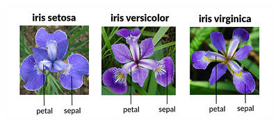

Figure 1: Measurements of sepal and petal lengths and width for three species of iris.

## Vectors

A vector is a list of elements that **must** be the same class of variable. Key skills include, creating, manipulating, changing the values in, and analyzing the contents of `vector` objects.

## Matrices

Matrices are a collection of data types in a 2- or 3-dimensional configuration, often used for mathematical modeling. Key skills are creating, accessing, and changing values in matrices.

## Lists

Lists are a structure that allows you to have *named* variables. Elements may be of different class and sizes. Key skills are extracting information from list-like objects (mostly from calling functions.)

## Data Frames

A `data.frame` is a dense data container similar to that of a spreadsheet where each column has data of the same type (e.g., Latitude, or Temperature) and each row represents a single record of measurements taken together (same time, same individual, etc.). The key skills here are creating (mostly loading from file), manipulating, extracting data from, and summarizing data contained in a `data.frame`.

## Communicating About Data

A main focus for this course is to be able to not only perform data analytics but to effectively communicate these results. This means that we need to develop skills necessary for including inferences from the data into our narrative.